Introduction to R and RMarkdown 4/1/2021

[Download materials](https://github.com/HSL-Data/BIMS_8382_Web/blob/master/public/zips/IntroR.zip?raw=true)

# Goal

Today’s goal will be to get us all a bit more familiar with R and RStudio. If you are a new user, welcome! If you are a returning user, perhaps there are some new tips or tricks you will learn today that will still make this class session helpful to you.

### Tour of RStudio

Welcome to R and RStudio!

- R is the underlying statistical computing environment. Think of this like a car’s engine.
- RStudio is the Integrated Development Environment that we use to interact with R, making writing and reading code a lot easier. Think of RStudio like the dashboard of the car.

### RStudio Panes

- On the top left is the **script** window. This is where we are going to write all of our code and notes.
- On the lower left there’s the **console** window. This is where R tells us what it thinks we told it and then the answer. This part is what R would look like (without RStudio)
- The top right has the **environment** and history tabs. The environment is a list of all objects that R knows and the history tab shows all the code that has been run.
- On the bottom right there’s a window with lots of tabs. Files provides the file structure in the working directory. **Plots** is where your visualizations will appear. Packages shows all of the installed packages and one that are checked are opened. **Help** is where we will learn about functions when we need assistance and the Viewer is for viewing other kinds of output, like web content.

### Creating a Project

Today you were provided with an RProject - it is the file that ends in .Rproj. When working on your own research or on the homework, you may need to create a project from scratch. The purpose of the project is to keep all of the files for each assigment / experiment together and organized. If you are already familiar with programming in other languages, the R Project sets your working directory.

RStudio projects make it straightforward to place your work into it’s own working directory. Creating a project takes away some of the stress of navigating through file directories and file paths. A project creates an encapsulation for source files, images, and anything else created during your R Session.

To create a Project, go to `File -> New Project` and then either create a new folder for your project by going to `New Directory` and browsing to where you want to place your project. Or, you can use a folder you have already created by going to `Existing Directory` and then navigating to your chosen folder.

### RStudio Global Options

- So that all of our set-ups look the same follow me to change a few settings. Go to Tools –> Global Options
  - In the General menu UNcheck all the boxes except the ones at the bottom for R updates. We do not want RStudio to open files without being told to
  - In the Code menu check the box for “Soft-wrap R source files”
  - (Optional): In the Code menu in the Display tab check the box for rainbow parentheses. This makes finding parentheses errors much easier!
  - In the R Markdown menu UNcheck the box for “Show output inline for all RMarkdown documents”

### RMarkdown bare basics

Today we are coding in an **RMarkdown** document. This is how I would recommend that you code your own projects too. RMarkdown interweaves prose with code. Prose are written in plain text and R code is contained in gray “r code chunks”.

Let’s write our first R code. To insert a new R code chunk press `Ctrl+Alt+I` OR `CMD+Option+I`.

# The arrow `<-` creates R objects

The arrow operator is created with the less than sign followed directly by the dash.

Every time you run code with the arrow, a new object is created. First, let’s create an object containing one value.

To run code in R, click anywhere in a line of code and press `CTRL+Enter/CMD+Enter`. You can also highlight a portion of the code that you wish to run. The result will be printed out to the console.

```r
myobj <- 55
```

Notice that when you run code that has an `<-` operator, the object is created in the environment. You will not see the value contained in the object in the console unless you ask R to print the object by calling its name:

```r
myobj
```

```
## [1] 55
```

```r
# R is case sensitive! Watch your casing and spelling
# MYobj
```

The text in green is a code comment. Comments in R are anything after a # *inside* an R chunk. Using a # outside the R chunks creates headings in our document.

Code comments can be helpful to documenting your code and turning off bits of code that you want to keep but that you do not want to run. I would encourage you to take extra notes during class as code comments using the # or in prose.

We can overwrite the value of object1 by re-assigning it

```r
myobj <- 70

#then call its name to see the object
myobj
```

```
## [1] 70
```

# Intro to functions

Inside the next R code chunk, let’s try a **function**. A function is a verb, telling R to do something. In R a function is a word followed by (). Whenever you see a word followed by (), that is a function. We’ll use the familiar `sqrt()` function to get the square root of a number, 5776. The things we provide on the inside of the function’s () are called **arguments**. Arguments change the way a function behaves.

Some functions don’t need any arguments

```r
Sys.Date() #get today's date
```

```
## [1] "2021-03-31"
```

Some functions just take a single argument. Let’s get the square root of 5776. Now let’s get the square root of myobj

```r
sqrt(5776)
```

```
## [1] 76
```

```r
# only returns the positive root

sqrt(myobj)
```

```
## [1] 8.3666
```

To learn more about a function, type `?` and then the function’s name

```r
?sqrt
```

Sometimes functions have arguments that have a default value. In those cases, you can override the default value by specifying your own.

For example, let’s look at the help page for the `rnorm()` function

```r
?rnorm
```

`rnorm()` generates random values from the normal distribution. We must supply the n argument since there is no default value, but there is a default value set for the mean and sd arguments.

```r
# 10 numbers with a mean = 0 and sd = 1 (bc those are the defaults)
rnorm(n = 10)
```

```
##  [1] -1.2028409 -1.1185097  0.2622616 -0.4487683  0.1057409  0.9876652
##  [7]  0.3098554 -1.0366747  0.1223878  0.9880535
```

```r
# change the defaults by specifying our own mean and sd
rnorm(n = 10, mean = 50, sd = 5)
```

```
##  [1] 54.84782 51.62811 48.77375 38.35052 50.00205 53.66975 53.06271 46.05291
##  [9] 55.06228 53.93099
```

```r
# what if we don't specify n?
#rnorm(mean = 50, sd = 5)
# we get an error
```

In the above examples, we have labeled our arguments according to their names in the help menu. If you do not label the arguments, they will be called into the function in the order given in the help menu.

```r
rnorm(10, 50, 5)
```

```
##  [1] 49.13190 39.69001 46.86824 43.25258 40.68062 51.50055 55.74547 49.19904
##  [9] 52.39407 48.49226
```

```r
#out of order, but works bc the arguments are labeled
rnorm(n = 10, sd = 5, mean = 50)
```

```
##  [1] 49.57370 37.72545 48.48207 48.28084 51.27211 48.58522 54.57775 51.71525
##  [9] 47.08037 43.52210
```

To improve readability (and accuracy) of your code, we would recommend labeling your arguments.

# EXERCISE

1. Use the arrow operator to create an object called myobj2 that stores 100 observations from a normal distribution with mean = 500 and sd = 100.
2. Call `hist(myobj2)` to create a histogram of your normal distribution

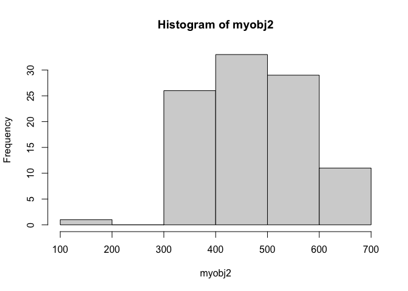

```r
myobj2 <- rnorm(n = 100, mean = 500, sd = 100)
hist(myobj2)
```

Look at the environment. What does it tell you about object2?

Let’s create some more R objects that are collections of several values. These are called **vectors**. A **vector** is a one-dimensional object. To create a vector of our own, we will use the function `c()`, which stands for concatenate or combine. Usually functions are named with a full word describing what they do but because combining items together is so common, this function gets a very short name.

```r
myobj3 <- c(55, 60, 35, 70)
```

Check out the environment now. It worked! We created myobj3

Let’s create another object containing a different type of data

```r
myobj4 <- c("Jack", "Leila", "Rohit")
```

# More Functions

Let’s `sum()` everything in myobj3 Now try the `mean()`

```r
sum(myobj3)
```

```
## [1] 220
```

```r
mean(myobj3)
```

```
## [1] 55
```

What happens if we try to `sum()` myobj4?

```r
#sum(myobj4)
```

What if we take the square root of myobj3?

```r
sqrt(myobj3)
```

```
## [1] 7.416198 7.745967 5.916080 8.366600
```

It worked! Most functions in R are **vectorized** meaning that they will work on a vector as well as a single value. This means that in R, we usually do not need to write loops like we would in other languages.

# Packages

Packages in R contain additional functions past the base R programming environment.

You can think of an R package like an app on your phone. Fist, we installed it from the internet when you ran the `install.packages()` function before class. You will not need to run this line again (until you update your R or your OS). When we called the `install.packages()` function, R went to the Comprehensive R Archive Network (CRAN) and downloaded the specified package. There are over 17K packages listed on CRAN, over 1900 on Bioconductor (bioinformatics packages), and many more under development on people’s github pages etc. You can be sure a package is safe to download if it comes from the CRAN or from Bioconductor.

The `library()` function loads the functions from the package(s) into R and allows you to use those functions during your current R session. We need to run the `library()` function each R session.

Run the following code to load the tidyverse library.

```r
#install.packages("tidyverse")
library(tidyverse)
```

If the above line says “Error there is no package called ‘tidyverse’”, try to install it by removing the # and running the `install.packages()` line. This may take a few minutes so be patient, follow along by taking notes, and feel free to email about anything you missed.

# Reading in Data

One example of functionality we gain from using the `tidyverse` package is the ability to read in csv files in a nice, neat way using the `read_csv()` function.

Today we are going to be looking at a dataset about Antarctic penguins. To read in the dataset, we will be pulling straight from our 8382 Github page.

Let’s run this chunk using a different method. Run the following code chunk by clicking in the upper right hand corner of the chunk on the green arrow.

```r
penguins <- read_csv("https://raw.githubusercontent.com/HSL-Data/BIMS_8382_Web/master/public/data/penguins.csv")
```

### View a dataset

To `View()` the dataset in spreadsheet form, we can click on the dataset’s name in the Environment tab. Notice that this action is accompanied by some code in the console telling us that we could also get there using code. Let’s try it both ways

```r
View(penguins) #captial letter V
```

Now is a great time to save our script. Go to File –> Save or `CTRL+S` (pc) or `CMD+S` (mac).

Where is the file saving? Because we have a project directory, our script saves to that folder.

### Functions to inspect dataframes

R has a few different types of objects. We already saw some vectors (one dimensional collection of items) before when we created myobj2, myobj3, and myobj4.

R’s dataframe objects store two dimensional, tabular, heterogeneous data. Two-dimensional and tabular meaning a table of rows and columns that form the 2 dimensions. Heterogeneous meaning that each column can contain a different type of data (i.e., one column Age is numeric while Gender is a character).

Let’s remind ourselves what our `penguins` dataset looks like by calling its name

```r
penguins
```

The `dim()` function will show us the dimensions of the `penguins` dataset.

```r
dim(penguins) #rows then columns
```

We can ask for the number of rows and the number of columns

```r
nrow(penguins)
ncol(penguins)
```

To see all the column headings we can call the function `names()`

```r
names(penguins)
```

And probably the two you’ll use the most to inspect data frames, because they are the most descriptive, are `summary()` and `str()`.

```r
summary(penguins)
str(penguins)
```

## Accessing variables from a dataframes

You might have noticed a `$` in front of the variable names in the `str()` output. That symbol is how we access individual variables, or columns, from a dataframe

The syntax we want is dataframe$columnname

Let’s look at the island column

```r
penguins$island
```

EEek! That function calls the whole column, which is 344 observations long. Usually printing out a long vector or column to the console is not useful. We will point this out if you do it in your homework, so please proofread the document you submit.

`head()` is a function allowing us to look at just the first 6 entries

```r
head(penguins$island)
```

What if we want to see the first 20 island values?

Let’s see if we can find out by calling help on the `head()` function

```r
?head
```

The help menu tells us what `head()` does and it also specifies the other arguments that we could input to the `head()` function in the Arguments section. This is always a good section to check out. Remember that an argument is an option we specify to a function to change how the function operates.

Let’s try adding the `n =` argument to `head()`

```r
head(penguins$island, n = 20)
head(penguins$island, 20)
```

Although we can specify the head function without naming the arguments, it is good practice to label the arguments to clarify what the code is doing. However, it is conventional to skip labeling the first argument, x, since its label is easily assumed.

You may have read in the help menu that `head()` has a companion function `tail()` that shows the last n rows

```r
tail(penguins$island, n = 20)
```

Let’s look at some descriptive statistics for our dataset

```r
mean(penguins$flipper_length_mm)
```

Take a look at the help menu for `mean()`

```r
?mean
```

Looking at the arguments section tells me that the argument I need to include is `na.rm = TRUE`

```r
mean(penguins$flipper_length_mm, na.rm = TRUE)
```

Luckily, this argument is the same for all of the descriptive statistics functions.

```r
sd(penguins$flipper_length_mm, na.rm = TRUE)
range(penguins$flipper_length_mm, na.rm = TRUE)
```

Descriptive statistics for a character variable (aka vector) will look different since we cannot calculate a mean. Let’s tabulate the frequencies of each island using the `table()` function.

```r
table(penguins$island)
```

```
##
##    Biscoe     Dream Torgersen
##       168       124        52
```

### is.na function

The `is.na()` function tells you whether or not a column has missing values. It will return a vector of TRUE/FALSE values, which can then be counted and explored.

```r
is.na(penguins$flipper_length_mm)
sum(is.na(penguins$flipper_length_mm))
```

# EXERCISE

1. Calculate the standard deviation of the body weight.
2. How many male penguins were observed?
3. What’s the range of `year` represented in the data?

```r
#1
sd(penguins$body_mass_g, na.rm = TRUE)

#2
table(penguins$sex)

#3
range(penguins$year)
```

# Open new RMarkdown and try to knit to PDF

The last thing we will do today is to create a PDF document like those that you will create for your homework. Follow along with us as we create a new RMarkdown file and knit it to PDF.